# CL Match day 5 Season 2627

X @Barts78 · Bluesky @barts78 · Mastodon @DrBarts · GitHub Barts78 · LinkedIn Phil-barter · Data: Opta

**Match Summary - By Game Quarter**

Club Brugge vs Liverpool - 25-11-2026

|  | Possession Possession % | Possession On Ball Time | Possession Touches | Possession PKBox Touches | Possession Field Tilt % | Shots Total Shots | Shots OFF Shots | Shots ONT Shots | Shots 6yrd box Shots | Shots PK Box Shots | Shots Outside Box Shots | Shots Blocked Shots | Shots BCs | Shots Goals | Shots xG | Shots NPxG | Shots xGOT | Threat EPV | Threat EPV % xG Con. | Threat EPV % NPxG Con. | Passes Attempted Passes | Passes Successful Passes | Passes Pass Success % | Passes Long Passes | Passes Long Ball Rate | Passes Crosses | Passes Cross Success % | Passes Corners | Passes Short Corners | … |
| --- | --- | --- | --- | --- | --- | --- | --- | --- | --- | --- | --- | --- | --- | --- | --- | --- | --- | --- | --- | --- | --- | --- | --- | --- | --- | --- | --- | --- | --- | --- |
| 1st Quarter |  |  |  |  |  |  |  |  |  |  |  |  |  |  |  |  |  |  |  |  |  |  |  |  |  |  |  |  |  | … |
| Club Brugge | 42.1% | 10.40 | 180 | 7 | 36.8% | 3 | 1 | 1 | 0 | 3 | 0 | 1 | 1 | 0 | 0.35 | 0.35 | 0.38 | 0.71 | 49.3% | 49.3% | 119 | 97 | 81.5% | 17 | 14.3% | 5 | 40.0% | 2 | 0 | … |
| Liverpool | 57.9% | 12.00 | 248 | 12 | 63.2% | 5 | 2 | 1 | 1 | 5 | 0 | 2 | 1 | 1 | 0.63 | 0.63 | 0.21 | 0.93 | 67.9% | 67.9% | 189 | 164 | 86.8% | 14 | 7.4% | 7 | 42.9% | 3 | 0 | … |
| 2nd Quarter |  |  |  |  |  |  |  |  |  |  |  |  |  |  |  |  |  |  |  |  |  |  |  |  |  |  |  |  |  | … |
| Club Brugge | 57.6% | 12.40 | 186 | 13 | 59.8% | 5 | 2 | 0 | 0 | 2 | 3 | 3 | 0 | 0 | 0.36 | 0.36 | 0.00 | 0.77 | 46.6% | 46.6% | 139 | 121 | 87.1% | 9 | 6.5% | 7 | 14.3% | 1 | 0 | … |
| Liverpool | 42.4% | 5.30 | 137 | 10 | 40.2% | 1 | 1 | 0 | 0 | 1 | 0 | 0 | 0 | 0 | 0.03 | 0.03 | 0.00 | 0.41 | 7.3% | 7.3% | 90 | 69 | 76.7% | 12 | 13.3% | 1 | 0.0% | 0 | 0 | … |
| 3rd Quarter |  |  |  |  |  |  |  |  |  |  |  |  |  |  |  |  |  |  |  |  |  |  |  |  |  |  |  |  |  | … |
| Club Brugge | 50.0% | 10.70 | 185 | 5 | 38.8% | 4 | 1 | 2 | 0 | 2 | 2 | 1 | 0 | 0 | 0.18 | 0.18 | 0.21 | 0.47 | 38.0% | 38.0% | 141 | 110 | 78.0% | 15 | 10.6% | 4 | 25.0% | 3 | 0 | … |
| Liverpool | 50.0% | 10.30 | 185 | 12 | 61.2% | 3 | 2 | 1 | 0 | 3 | 0 | 0 | 1 | 0 | 0.55 | 0.55 | 0.52 | 0.68 | 81.2% | 81.2% | 131 | 109 | 83.2% | 11 | 8.4% | 4 | 0.0% | 0 | 0 | … |
| 4th Quarter |  |  |  |  |  |  |  |  |  |  |  |  |  |  |  |  |  |  |  |  |  |  |  |  |  |  |  |  |  | … |
| Club Brugge | 63.6% | 9.60 | 182 | 8 | 75.7% | 5 | 1 | 2 | 0 | 2 | 3 | 2 | 0 | 0 | 0.27 | 0.27 | 0.28 | 0.77 | 34.9% | 34.9% | 143 | 131 | 91.6% | 4 | 2.8% | 4 | 50.0% | 2 | 0 | … |
| Liverpool | 36.4% | 7.40 | 104 | 6 | 24.3% | 4 | 1 | 2 | 0 | 3 | 1 | 1 | 1 | 2 | 0.77 | 0.77 | 0.34 | 0.40 | 190.6% | 190.6% | 60 | 45 | 75.0% | 8 | 13.3% | 2 | 100.0% | 1 | 0 | … |

X @Barts78 · Bluesky @barts78 · Mastodon @DrBarts · GitHub Barts78 · LinkedIn Phil-barter · Data: Opta

**Match Summary - By Game State**

Club Brugge vs Liverpool - 25-11-2026

|  | Possession Possession % | Possession On Ball Time | Possession Touches | Possession PKBox Touches | Possession Field Tilt % | Shots Total Shots | Shots OFF Shots | Shots SoT | Shots 6yrd box Shots | Shots PK Box Shots | Shots Outside Box Shots | Shots Blocked Shots | Shots BCs | Shots Goals | Shots xG | Shots NPxG | Shots xGOT | Threat EPV | Threat EPV % xG Con. | Threat EPV % NPxG Con. | Passes Attempted Passes | Passes Successful Passes | Passes Pass Success % | Passes Long Passes | Passes Long Ball Rate | Passes Crosses | Passes Cross Success % | Passes Corners | Passes Short Corners | … |
| --- | --- | --- | --- | --- | --- | --- | --- | --- | --- | --- | --- | --- | --- | --- | --- | --- | --- | --- | --- | --- | --- | --- | --- | --- | --- | --- | --- | --- | --- | --- |
| Away Garbage Time |  |  |  |  |  |  |  |  |  |  |  |  |  |  |  |  |  |  |  |  |  |  |  |  |  |  |  |  |  | … |
| Club Brugge | 62.7% | 5.80 | 121 | 3 | 76.4% | 3 | 1 | 1 | 0 | 1 | 2 | 1 | 0 | 0 | 0.14 | 0.14 | 0.25 | 0.45 | 31.4% | 31.4% | 93 | 85 | 91.4% | 2 | 2.1% | 3 | 33.3% | 2 | 0 | … |
| Liverpool | 37.3% | 4.80 | 72 | 4 | 23.6% | 2 | 1 | 1 | 0 | 2 | 0 | 0 | 1 | 1 | 0.61 | 0.61 | 0.31 | 0.30 | 200.7% | 200.7% | 43 | 32 | 74.4% | 5 | 11.6% | 2 | 100.0% | 1 | 0 | … |
| Away Lead |  |  |  |  |  |  |  |  |  |  |  |  |  |  |  |  |  |  |  |  |  |  |  |  |  |  |  |  |  | … |
| Club Brugge | 53.0% | 32.70 | 534 | 25 | 50.7% | 13 | 4 | 4 | 0 | 7 | 6 | 5 | 1 | 0 | 0.94 | 0.94 | 0.62 | 2.05 | 45.8% | 45.8% | 396 | 333 | 84.1% | 34 | 8.6% | 16 | 31.2% | 5 | 0 | … |
| Liverpool | 47.0% | 23.20 | 473 | 32 | 49.3% | 9 | 4 | 2 | 1 | 8 | 1 | 3 | 1 | 1 | 0.90 | 0.90 | 0.55 | 1.76 | 51.2% | 51.2% | 324 | 265 | 81.8% | 31 | 9.6% | 9 | 33.3% | 2 | 0 | … |
| Draw |  |  |  |  |  |  |  |  |  |  |  |  |  |  |  |  |  |  |  |  |  |  |  |  |  |  |  |  |  | … |
| Club Brugge | 37.7% | 4.60 | 78 | 5 | 28.6% | 1 | 0 | 0 | 0 | 1 | 0 | 1 | 0 | 0 | 0.08 | 0.08 | 0.00 | 0.23 | 34.8% | 34.8% | 53 | 41 | 77.4% | 9 | 17.0% | 1 | 0.0% | 1 | 0 | … |
| Liverpool | 62.3% | 7.10 | 129 | 4 | 71.4% | 2 | 1 | 1 | 0 | 2 | 0 | 0 | 1 | 1 | 0.47 | 0.47 | 0.21 | 0.36 | 132.4% | 132.4% | 103 | 90 | 87.4% | 9 | 8.7% | 3 | 0.0% | 1 | 0 | … |

X @Barts78 · Bluesky @barts78 · Mastodon @DrBarts · GitHub Barts78 · LinkedIn Phil-barter · Data: Opta

**Season Summary Tables**

**Season Summary - Full Games**

Up to Club Brugge vs Liverpool - 25-11-2026

| Possession % | Touches | PKBox Touches | Field Tilt % | Total Shots | OFF Shots | SoT | 6yrd box Shots | PK Box Shots | Outside Box Shots | BCs | Goals | xG | NPxG | xGOT | EPV | EPV % xG Con. | Attempted Passes | Successful Passes | Pass Success % | Long Passes | Long Ball Rate | Crosses | Cross Success % | Corners | Short Corners | Possession Control | Poss Control /100 Touches | EPV % NPxG Con. |
| --- | --- | --- | --- | --- | --- | --- | --- | --- | --- | --- | --- | --- | --- | --- | --- | --- | --- | --- | --- | --- | --- | --- | --- | --- | --- | --- | --- | --- |
| All Oppo |  |  |  |  |  |  |  |  |  |  |  |  |  |  |  |  |  |  |  |  |  |  |  |  |  |  |  |  |
| 46.3% | 3,079 | 116 | 39.7% | 69 | 26 | 24 | 6 | 42 | 27 | 13 | 10 | 7.38 | 7.38 | 8.63 | 9.55 | 77.3% | 2126 | 1751 | 82.4% | 233 | 11.0% | 70 | 22.9% | 22 | 4 | -344 | -11.2 | 77.3% |
| Liverpool |  |  |  |  |  |  |  |  |  |  |  |  |  |  |  |  |  |  |  |  |  |  |  |  |  |  |  |  |
| 53.7% | 3,566 | 209 | 60.3% | 97 | 42 | 30 | 7 | 77 | 20 | 18 | 17 | 11.20 | 11.20 | 11.44 | 14.58 | 76.8% | 2538 | 2203 | 86.8% | 223 | 8.8% | 112 | 25.0% | 41 | 5 | -335 | -9.4 | 76.8% |

X @Barts78 · Bluesky @barts78 · Mastodon @DrBarts · GitHub Barts78 · LinkedIn Phil-barter · Data: Opta

**Season Summary - By Half**

Up to Club Brugge vs Liverpool - 25-11-2026

|  | Possession Possession % | Possession Touches | Possession PKBox Touches | Possession Field Tilt % | Shots Total Shots | Shots OFF Shots | Shots SoT | Shots 6yrd box Shots | Shots PK Box Shots | Shots Outside Box Shots | Shots BCs | Shots Goals | Shots xG | Shots NPxG | Shots xGOT | Threat EPV | Threat EPV % xG Con. | Threat EPV % NPxG Con. | Passes Attempted Passes | Passes Successful Passes | Passes Pass Success % | Passes Long Passes | Passes Long Ball Rate | Passes Crosses | Passes Cross Success % | Passes Corners | Passes Short Corners | Possession Control | Poss Control /100 Touches | … |
| --- | --- | --- | --- | --- | --- | --- | --- | --- | --- | --- | --- | --- | --- | --- | --- | --- | --- | --- | --- | --- | --- | --- | --- | --- | --- | --- | --- | --- | --- | --- |
| First Half |  |  |  |  |  |  |  |  |  |  |  |  |  |  |  |  |  |  |  |  |  |  |  |  |  |  |  |  |  | … |
| All Oppo | 43.8% | 1,471 | 60 | 33.4% | 35 | 15 | 9 | 3 | 21 | 14 | 5 | 4 | 3.76 | 3.76 | 2.49 | 4.40 | 85.5% | 85.5% | 976 | 786 | 80.5% | 124 | 12.7% | 27 | 22.2% | 11 | 3 |  |  | … |
| Liverpool | 56.2% | 1,885 | 107 | 66.6% | 48 | 22 | 13 | 4 | 38 | 10 | 9 | 8 | 5.01 | 5.01 | 5.13 | 7.02 | 71.3% | 71.3% | 1359 | 1182 | 87.0% | 106 | 7.8% | 62 | 19.4% | 23 | 3 | -190 | -10.1 | … |
| Second Half |  |  |  |  |  |  |  |  |  |  |  |  |  |  |  |  |  |  |  |  |  |  |  |  |  |  |  |  |  | … |
| All Oppo | 48.9% | 1,608 | 56 | 46.0% | 34 | 11 | 15 | 3 | 21 | 13 | 8 | 6 | 3.62 | 3.62 | 6.14 | 5.15 | 70.3% | 70.3% | 1150 | 965 | 83.9% | 109 | 9.5% | 43 | 23.3% | 11 | 1 | -176 | -10.9 | … |
| Liverpool | 51.1% | 1,681 | 102 | 54.0% | 49 | 20 | 17 | 3 | 39 | 10 | 9 | 9 | 6.19 | 6.19 | 6.31 | 7.56 | 81.9% | 81.9% | 1179 | 1021 | 86.6% | 117 | 9.9% | 50 | 32.0% | 18 | 2 | -145 | -8.6 | … |

X @Barts78 · Bluesky @barts78 · Mastodon @DrBarts · GitHub Barts78 · LinkedIn Phil-barter · Data: Opta

**Season Summary - By Game Period**

Up to Club Brugge vs Liverpool - 25-11-2026

|  | Possession Possession % | Possession Touches | Possession PKBox Touches | Possession Field Tilt % | Shots Total Shots | Shots OFF Shots | Shots ONT Shots | Shots 6yrd box Shots | Shots PK Box Shots | Shots Outside Box Shots | Shots BCs | Shots Goals | Shots xG | Shots NPxG | Shots xGOT | Threat EPV | Threat EPV % xG Con. | Threat EPV % NPxG Con. | Passes Attempted Passes | Passes Successful Passes | Passes Pass Success % | Passes Long Passes | Passes Long Ball Rate | Passes Crosses | Passes Cross Success % | Passes Corners | Passes Short Corners | Possession Control | Poss Control /100 Touches | … |
| --- | --- | --- | --- | --- | --- | --- | --- | --- | --- | --- | --- | --- | --- | --- | --- | --- | --- | --- | --- | --- | --- | --- | --- | --- | --- | --- | --- | --- | --- | --- |
| 0 - 15 |  |  |  |  |  |  |  |  |  |  |  |  |  |  |  |  |  |  |  |  |  |  |  |  |  |  |  |  |  | … |
| All Oppo | 43.9% | 542 | 23 | 33.6% | 8 | 3 | 2 | 1 | 6 | 2 | 1 | 1 | 0.67 | 0.67 | 0.60 | 1.33 | 50.5% | 50.5% | 358 | 277 | 77.4% | 50 | 14.0% | 10 | 20.0% | 5 | 1 |  |  | … |
| Liverpool | 56.1% | 693 | 29 | 66.4% | 17 | 10 | 3 | 1 | 13 | 4 | 4 | 1 | 1.85 | 1.85 | 0.61 | 1.98 | 93.4% | 93.4% | 504 | 433 | 85.9% | 46 | 9.1% | 15 | 6.7% | 5 | 1 | -74 | -10.7 | … |
| 16 - 30 |  |  |  |  |  |  |  |  |  |  |  |  |  |  |  |  |  |  |  |  |  |  |  |  |  |  |  |  |  | … |
| All Oppo | 40.5% | 427 | 16 | 26.5% | 12 | 2 | 5 | 1 | 6 | 6 | 4 | 3 | 2.11 | 2.11 | 1.74 | 1.38 | 152.7% | 152.7% | 279 | 235 | 84.2% | 38 | 13.6% | 5 | 20.0% | 2 | 1 | -34 | -8.0 | … |
| Liverpool | 59.5% | 628 | 35 | 73.5% | 13 | 4 | 4 | 1 | 13 | 0 | 0 | 3 | 0.87 | 0.87 | 0.72 | 2.60 | 33.5% | 33.5% | 468 | 424 | 90.6% | 28 | 6.0% | 27 | 25.9% | 10 | 0 | -50 | -8.0 | … |
| 31 - 45 |  |  |  |  |  |  |  |  |  |  |  |  |  |  |  |  |  |  |  |  |  |  |  |  |  |  |  |  |  | … |
| All Oppo | 47.1% | 502 | 21 | 40.8% | 15 | 10 | 2 | 1 | 9 | 6 | 0 | 0 | 0.98 | 0.98 | 0.15 | 1.69 | 58.0% | 58.0% | 339 | 274 | 80.8% | 36 | 10.6% | 12 | 25.0% | 4 | 1 | -60 | -12.0 | … |
| Liverpool | 52.9% | 564 | 43 | 59.2% | 18 | 8 | 6 | 2 | 12 | 6 | 5 | 4 | 2.29 | 2.29 | 3.80 | 2.44 | 93.7% | 93.7% | 387 | 325 | 84.0% | 32 | 8.3% | 20 | 20.0% | 8 | 2 | -66 | -11.7 | … |
| 46 - 60 |  |  |  |  |  |  |  |  |  |  |  |  |  |  |  |  |  |  |  |  |  |  |  |  |  |  |  |  |  | … |
| All Oppo | 40.7% | 471 | 9 | 22.3% | 7 | 2 | 4 | 0 | 5 | 2 | 0 | 0 | 0.32 | 0.32 | 0.95 | 0.84 | 38.3% | 38.3% | 295 | 222 | 75.3% | 38 | 12.9% | 10 | 20.0% | 3 | 0 | -57 | -12.1 | … |
| Liverpool | 59.3% | 685 | 45 | 77.7% | 21 | 9 | 8 | 0 | 14 | 7 | 2 | 2 | 1.61 | 1.61 | 2.09 | 2.44 | 65.8% | 65.8% | 503 | 445 | 88.5% | 32 | 6.4% | 27 | 18.5% | 8 | 1 | -50 | -7.3 | … |
| 61 - 75 |  |  |  |  |  |  |  |  |  |  |  |  |  |  |  |  |  |  |  |  |  |  |  |  |  |  |  |  |  | … |
| All Oppo | 52.6% | 499 | 25 | 53.8% | 12 | 2 | 6 | 2 | 7 | 5 | 4 | 3 | 2.06 | 2.06 | 2.81 | 1.62 | 126.8% | 126.8% | 390 | 339 | 86.9% | 32 | 8.2% | 13 | 7.7% | 4 | 1 | -56 | -11.2 | … |
| Liverpool | 47.4% | 450 | 31 | 46.2% | 14 | 4 | 5 | 3 | 13 | 1 | 6 | 5 | 3.23 | 3.23 | 3.45 | 2.56 | 126.1% | 126.1% | 303 | 266 | 87.8% | 35 | 11.6% | 7 | 57.1% | 3 | 0 | -32 | -7.1 | … |
| 76 - 90 |  |  |  |  |  |  |  |  |  |  |  |  |  |  |  |  |  |  |  |  |  |  |  |  |  |  |  |  |  | … |
| All Oppo | 56.3% | 557 | 20 | 62.6% | 14 | 7 | 5 | 1 | 9 | 5 | 4 | 3 | 1.19 | 1.19 | 2.38 | 2.53 | 46.9% | 46.9% | 410 | 362 | 88.3% | 31 | 7.6% | 19 | 36.8% | 4 | 0 | -51 | -9.2 | … |
| Liverpool | 43.7% | 432 | 21 | 37.4% | 12 | 6 | 4 | 0 | 10 | 2 | 1 | 2 | 1.28 | 1.28 | 0.77 | 2.22 | 57.6% | 57.6% | 280 | 234 | 83.6% | 35 | 12.5% | 14 | 50.0% | 6 | 1 | -48 | -11.1 | … |
| 90 + |  |  |  |  |  |  |  |  |  |  |  |  |  |  |  |  |  |  |  |  |  |  |  |  |  |  |  |  |  | … |
| All Oppo | 41.5% | 81 | 2 | 28.1% | 1 | 0 | 0 | 0 | 0 | 1 | 0 | 0 | 0.05 | 0.05 | 0.00 | 0.15 | 32.9% | 32.9% | 55 | 42 | 76.4% | 8 | 14.6% | 1 | 0.0% | 0 | 0 | -12 | -14.8 | … |
| Liverpool | 58.5% | 114 | 5 | 71.9% | 2 | 1 | 0 | 0 | 2 | 0 | 0 | 0 | 0.07 | 0.07 | 0.00 | 0.33 | 21.4% | 21.4% | 93 | 76 | 81.7% | 15 | 16.1% | 2 | 0.0% | 1 | 0 | -15 | -13.2 | … |

X @Barts78 · Bluesky @barts78 · Mastodon @DrBarts · GitHub Barts78 · LinkedIn Phil-barter · Data: Opta

**Season Summary - By Game State**

Up to Club Brugge vs Liverpool - 25-11-2026

|  | Possession Possession % | Possession Touches | Possession PKBox Touches | Possession Field Tilt % | Shots Total Shots | Shots OFF Shots | Shots SoT | Shots 6yrd box Shots | Shots PK Box Shots | Shots Outside Box Shots | Shots BCs | Shots Goals | Shots xG | Shots NPxG | Shots xGOT | Threat EPV | Threat EPV % xG Con. | Threat EPV % NPxG Con. | Passes Attempted Passes | Passes Successful Passes | Passes Pass Success % | Passes Long Passes | Passes Long Ball Rate | Passes Crosses | Passes Cross Success % | Passes Corners | Passes Short Corners | Possession Control | Poss Control /100 Touches | … |
| --- | --- | --- | --- | --- | --- | --- | --- | --- | --- | --- | --- | --- | --- | --- | --- | --- | --- | --- | --- | --- | --- | --- | --- | --- | --- | --- | --- | --- | --- | --- |
| Away Garbage Time |  |  |  |  |  |  |  |  |  |  |  |  |  |  |  |  |  |  |  |  |  |  |  |  |  |  |  |  |  | … |
| All Oppo | 44.8% | 553 | 19 | 47.4% | 14 | 8 | 5 | 2 | 10 | 4 | 4 | 3 | 2.04 | 2.04 | 2.43 | 1.78 | 114.5% | 114.5% | 398 | 344 | 86.4% | 28 | 7.0% | 16 | 18.8% | 3 | 0 |  |  | … |
| Liverpool | 55.2% | 681 | 40 | 52.6% | 19 | 8 | 7 | 2 | 15 | 4 | 6 | 6 | 3.44 | 3.44 | 4.33 | 3.24 | 106.2% | 106.2% | 506 | 454 | 89.7% | 37 | 7.3% | 16 | 50.0% | 8 | 3 | -58 | -8.5 | … |
| Away Lead |  |  |  |  |  |  |  |  |  |  |  |  |  |  |  |  |  |  |  |  |  |  |  |  |  |  |  |  |  | … |
| All Oppo | 49.1% | 959 | 36 | 39.4% | 26 | 5 | 9 | 2 | 14 | 12 | 4 | 3 | 2.94 | 2.94 | 2.72 | 3.14 | 93.6% | 93.6% | 679 | 559 | 82.3% | 74 | 10.9% | 18 | 27.8% | 9 | 3 | -114 | -11.9 | … |
| Liverpool | 50.9% | 994 | 65 | 60.6% | 21 | 7 | 7 | 2 | 18 | 3 | 4 | 4 | 2.34 | 2.34 | 2.71 | 3.59 | 65.3% | 65.3% | 693 | 586 | 84.6% | 56 | 8.1% | 24 | 20.8% | 6 | 0 | -77 | -7.7 | … |
| Draw |  |  |  |  |  |  |  |  |  |  |  |  |  |  |  |  |  |  |  |  |  |  |  |  |  |  |  |  |  | … |
| All Oppo | 39.2% | 890 | 35 | 27.1% | 19 | 8 | 7 | 1 | 12 | 7 | 3 | 3 | 1.63 | 1.63 | 2.59 | 2.37 | 68.9% | 68.9% | 540 | 409 | 75.7% | 83 | 15.4% | 19 | 21.1% | 7 | 1 | -101 | -11.3 | … |
| Liverpool | 60.8% | 1,379 | 75 | 72.9% | 43 | 20 | 13 | 3 | 31 | 12 | 7 | 6 | 4.45 | 4.45 | 3.52 | 5.53 | 80.5% | 80.5% | 1011 | 898 | 88.8% | 75 | 7.4% | 56 | 19.6% | 22 | 2 | -151 | -10.9 | … |
| Home Garbage Time |  |  |  |  |  |  |  |  |  |  |  |  |  |  |  |  |  |  |  |  |  |  |  |  |  |  |  |  |  | … |
| All Oppo | 61.7% | 182 | 9 | 63.7% | 4 | 1 | 2 | 0 | 3 | 1 | 1 | 1 | 0.37 | 0.37 | 0.77 | 0.76 | 48.6% | 48.6% | 140 | 129 | 92.1% | 10 | 7.1% | 3 | 33.3% | 0 | 0 | -17 | -9.3 | … |
| Liverpool | 38.3% | 113 | 9 | 36.3% | 3 | 2 | 0 | 0 | 3 | 0 | 0 | 0 | 0.16 | 0.16 | 0.00 | 0.44 | 36.6% | 36.6% | 76 | 63 | 82.9% | 13 | 17.1% | 1 | 0.0% | 0 | 0 | -4 | -3.5 | … |
| Home Lead |  |  |  |  |  |  |  |  |  |  |  |  |  |  |  |  |  |  |  |  |  |  |  |  |  |  |  |  |  | … |
| All Oppo | 55.4% | 495 | 17 | 51.9% | 6 | 4 | 1 | 1 | 3 | 3 | 1 | 0 | 0.40 | 0.40 | 0.12 | 1.50 | 26.7% | 26.7% | 369 | 310 | 84.0% | 38 | 10.3% | 14 | 21.4% | 3 | 0 | -62 | -12.5 | … |
| Liverpool | 44.6% | 399 | 20 | 48.1% | 11 | 5 | 3 | 0 | 10 | 1 | 1 | 1 | 0.81 | 0.81 | 0.88 | 1.79 | 45.2% | 45.2% | 252 | 202 | 80.2% | 42 | 16.7% | 15 | 26.7% | 5 | 0 | -45 | -11.3 | … |

X @Barts78 · Bluesky @barts78 · Mastodon @DrBarts · GitHub Barts78 · LinkedIn Phil-barter · Data: Opta

**Season Summary - By Match Day**

Up to Club Brugge vs Liverpool - 25-11-2026

|  | Fixture | Possession Possession % | Possession Touches | Possession PKBox Touches | Possession Field Tilt % | Shots Total Shots | Shots OFF Shots | Shots SoT | Shots 6yrd box Shots | Shots PK Box Shots | Shots Outside Box Shots | Shots BCs | Shots Goals | Shots xG | Shots NPxG | Shots xGOT | Threat EPV | Threat EPV % xG Con. | Threat EPV % NPxG Con. | Passes Attempted Passes | Passes Successful Passes | Passes Pass Success % | Passes Long Passes | Passes Long Ball Rate | Passes Crosses | Passes Cross Success % | Passes Corners | Passes Short Corners | Possession Control | … |
| --- | --- | --- | --- | --- | --- | --- | --- | --- | --- | --- | --- | --- | --- | --- | --- | --- | --- | --- | --- | --- | --- | --- | --- | --- | --- | --- | --- | --- | --- | --- |
| 1 |  |  |  |  |  |  |  |  |  |  |  |  |  |  |  |  |  |  |  |  |  |  |  |  |  |  |  |  |  | … |
| All Oppo | Liverpool vs Atletico | 53.2% | 708 | 19 | 41.2% | 9 | 4 | 4 | 1 | 4 | 5 | 1 | 1 | 0.81 | 0.81 | 0.60 | 1.84 | 44.0% | 44.0% | 515 | 438 | 85.0% | 54 | 10.5% | 15 | 26.7% | 5 | 1 |  | … |
| Liverpool | Liverpool vs Atletico | 46.8% | 622 | 35 | 58.8% | 14 | 5 | 5 | 0 | 12 | 2 | 4 | 2 | 1.70 | 1.70 | 1.63 | 2.30 | 74.0% | 74.0% | 421 | 355 | 84.3% | 50 | 11.9% | 17 | 17.6% | 7 | 2 | -68 | … |
| 2 |  |  |  |  |  |  |  |  |  |  |  |  |  |  |  |  |  |  |  |  |  |  |  |  |  |  |  |  |  | … |
| All Oppo | LASK vs Liverpool | 38.1% | 479 | 24 | 35.4% | 12 | 7 | 4 | 3 | 10 | 2 | 4 | 3 | 2.02 | 2.02 | 2.18 | 1.63 | 123.6% | 123.6% | 310 | 251 | 81.0% | 35 | 11.3% | 17 | 17.6% | 3 | 1 | -63 | … |
| Liverpool | LASK vs Liverpool | 61.9% | 778 | 51 | 64.6% | 26 | 12 | 8 | 2 | 20 | 6 | 5 | 6 | 3.33 | 3.33 | 3.70 | 3.71 | 89.8% | 89.8% | 576 | 524 | 91.0% | 41 | 7.1% | 19 | 36.8% | 11 | 3 | -67 | … |
| 3 |  |  |  |  |  |  |  |  |  |  |  |  |  |  |  |  |  |  |  |  |  |  |  |  |  |  |  |  |  | … |
| All Oppo | Liverpool vs Villarreal | 48.7% | 716 | 22 | 33.9% | 14 | 2 | 5 | 0 | 9 | 5 | 3 | 3 | 1.61 | 1.61 | 2.14 | 1.66 | 96.9% | 96.9% | 499 | 417 | 83.6% | 50 | 10.0% | 8 | 12.5% | 2 | 1 | -83 | … |
| Liverpool | Liverpool vs Villarreal | 51.3% | 755 | 45 | 66.1% | 22 | 8 | 7 | 2 | 14 | 8 | 3 | 4 | 2.38 | 2.38 | 3.85 | 2.92 | 81.4% | 81.4% | 542 | 464 | 85.6% | 43 | 7.9% | 20 | 15.0% | 7 | 0 | -51 | … |
| 4 |  |  |  |  |  |  |  |  |  |  |  |  |  |  |  |  |  |  |  |  |  |  |  |  |  |  |  |  |  | … |
| All Oppo | Fenerbahce vs Liverpool | 37.5% | 443 | 18 | 33.0% | 17 | 8 | 6 | 2 | 10 | 7 | 4 | 3 | 1.78 | 1.78 | 2.84 | 1.68 | 106.0% | 106.0% | 260 | 186 | 71.5% | 49 | 18.9% | 10 | 20.0% | 4 | 1 | -58 | … |
| Liverpool | Fenerbahce vs Liverpool | 62.5% | 737 | 38 | 67.0% | 22 | 11 | 6 | 2 | 19 | 3 | 3 | 2 | 1.81 | 1.81 | 1.19 | 3.23 | 56.0% | 56.0% | 529 | 473 | 89.4% | 44 | 8.3% | 42 | 23.8% | 12 | 0 | -86 | … |
| 5 |  |  |  |  |  |  |  |  |  |  |  |  |  |  |  |  |  |  |  |  |  |  |  |  |  |  |  |  |  | … |
| All Oppo | Club Brugge vs Liverpool | 52.1% | 733 | 33 | 53.0% | 17 | 5 | 5 | 0 | 9 | 8 | 1 | 0 | 1.16 | 1.16 | 0.87 | 2.73 | 42.5% | 42.5% | 542 | 459 | 84.7% | 45 | 8.3% | 20 | 30.0% | 8 | 0 | -76 | … |
| Liverpool | Club Brugge vs Liverpool | 47.9% | 674 | 40 | 47.0% | 13 | 6 | 4 | 1 | 12 | 1 | 3 | 3 | 1.98 | 1.98 | 1.07 | 2.42 | 81.9% | 81.9% | 470 | 387 | 82.3% | 45 | 9.6% | 14 | 35.7% | 4 | 0 | -63 | … |

X @Barts78 · Bluesky @barts78 · Mastodon @DrBarts · GitHub Barts78 · LinkedIn Phil-barter · Data: Opta

**Match Goals Probablity xG only**

[figure not shown]

**Match Goals Probablity Blended**

[figure not shown]

**Match Goals Probablity Optimistic**

[figure not shown]

**Match Goals Probablity Pessimistic**

[figure not shown]

**Match Result Probablity - All Models**

[figure not shown]

**Match Result Probablity xG only**

[figure not shown]

**Match Result Probablity Blended**

[figure not shown]

**Match Result Probablity Optimistic**

[figure not shown]

**Match Result Probablity Pessimistic**

[figure not shown]

Home Match territory plot

[figure not shown]

Away Match teratitory plot

[figure not shown]

Substitution Impact

**Substitution Impact - Before and After Each Sub Window**

Club Brugge vs Liverpool - 25-11-2026 | xG and EPV per 10 minutes, field tilt and PPDA within each window

|  | Mins | Subs on | Score | Club Brugge xG/10 | Club Brugge EPV/10 | Club Brugge Field tilt % | Club Brugge PPDA | Liverpool xG/10 | Liverpool EPV/10 | Liverpool Field tilt % | Liverpool PPDA |
| --- | --- | --- | --- | --- | --- | --- | --- | --- | --- | --- | --- |
| 0'-41' | 41 | Starting XIs | 0-0 | 0.14 | 0.27 | 41% | 13.64 | 0.16 | 0.31 | 59% | 13.70 |
| 41'-77' | 36 | LIV: Ngumoha | 0-1 | 0.09 | 0.26 | 54% | 11.20 | 0.15 | 0.21 | 46% | 21.25 |
| 77'-87' | 10 | CLU: Vermant, Diakhon \| LIV: van Dijk, Mac Allister | 0-1 | 0.19 | 0.44 | 85% | 6.33 | 0.68 | 0.12 | 15% | 22.00 |
| 87'-93' | 6 | CLU: Siquet, Tsawa \| LIV: Chambers, Koumas | 0-3 | 0.08 | 0.24 | 52% | 10.00 | 0.15 | 0.34 | 48% | - |
| 93'-97' | 5 | CLU: Dams | 0-3 | 0.06 | 0.17 | 67% | 6.00 | 0.00 | 0.16 | 33% | - |

Windows split at each substitution (subs within 3 minutes are grouped). Short windows are noisy, so read alongside the minutes column.  
X @Barts78 · Bluesky @barts78 · Mastodon @DrBarts · GitHub Barts78 · LinkedIn Phil-barter · Data: Opta

Match vs Season Average

[figure not shown]

Home Pass Maps

[figure not shown]

Away Pass Maps

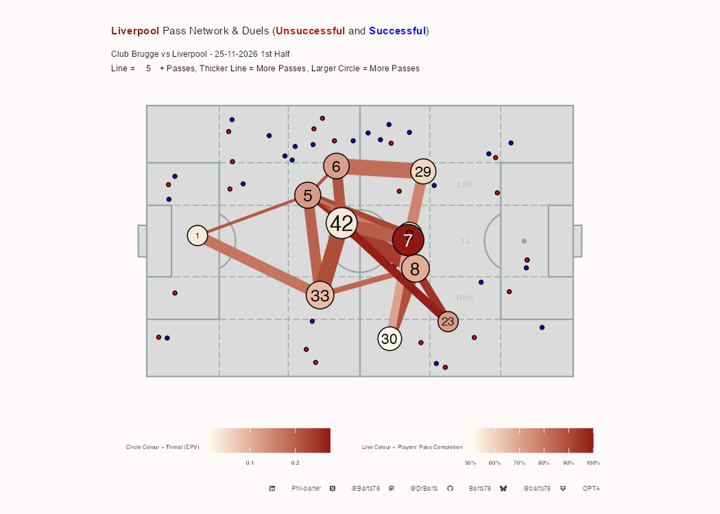

Home Pass Maps by Time

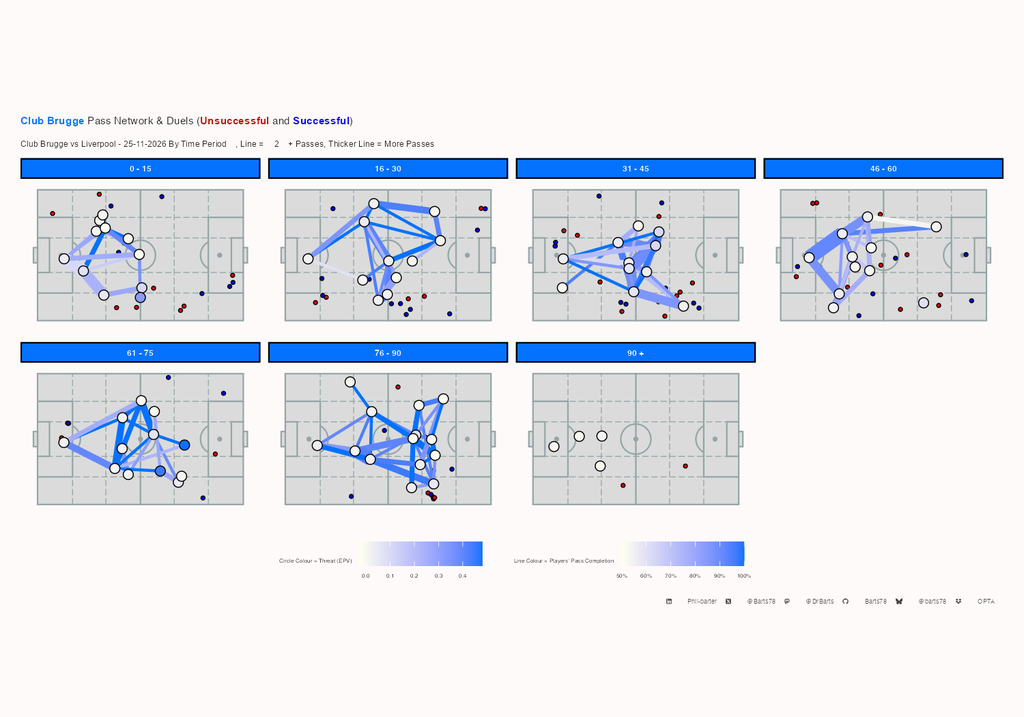

Away Pass Maps by Time

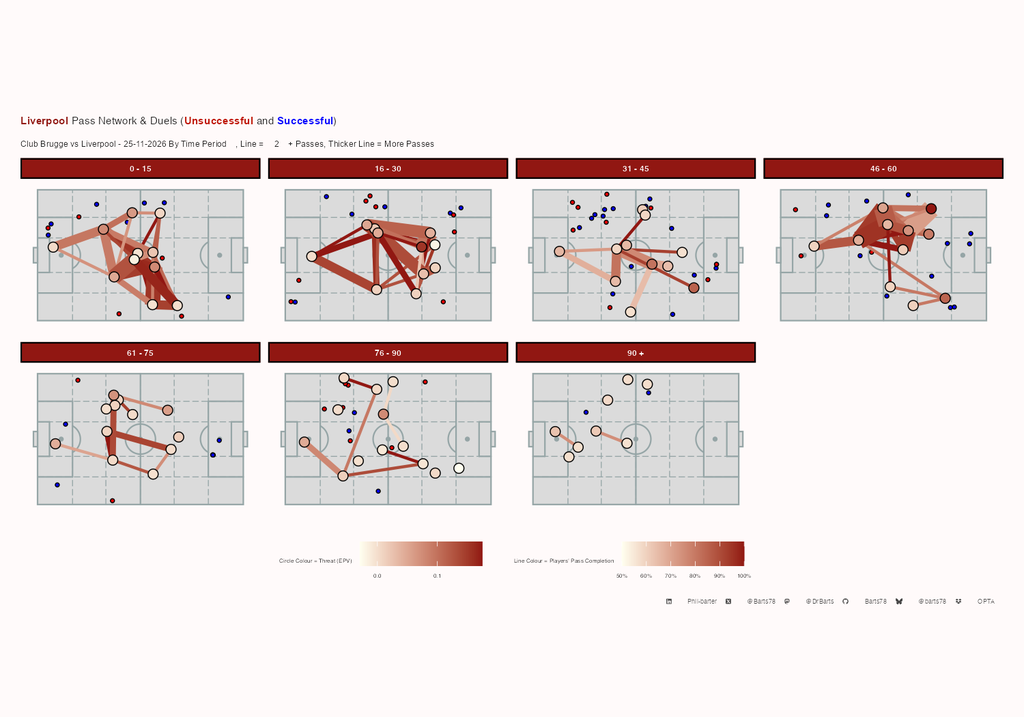

Home Attacking Pass Maps

[figure not shown]

Away Attacking Pass Maps

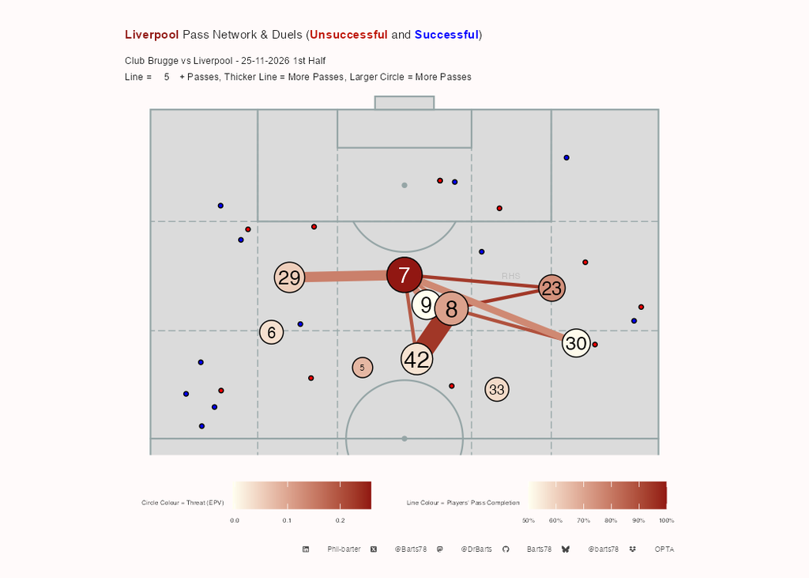

Home Attacking Pass Maps by Time

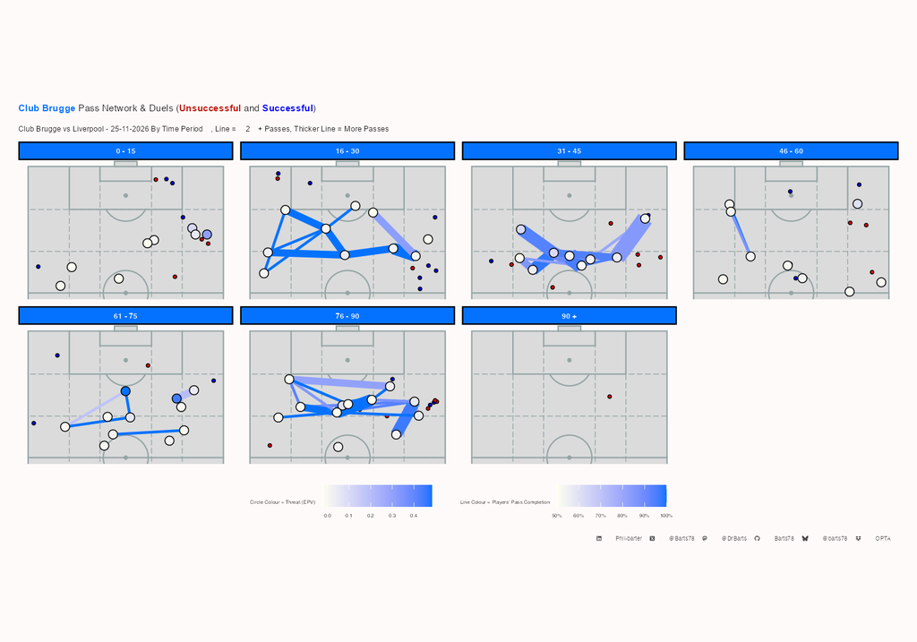

Away Attacking Pass Maps by Time

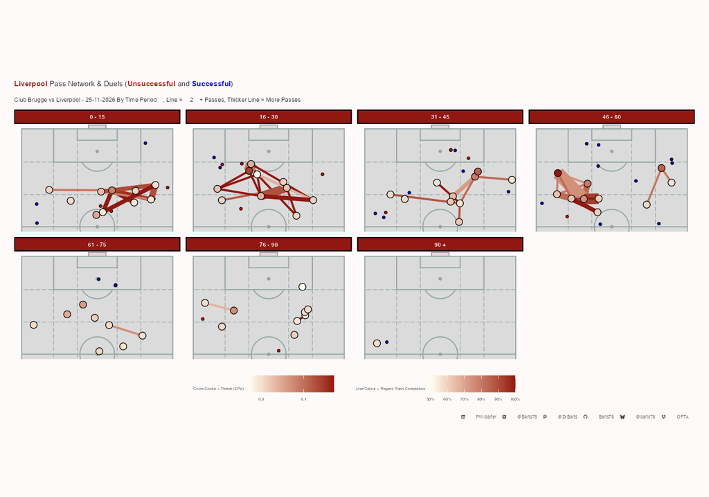

**Pass Connections by Passer**

Club Brugge Open Play Passing connections

Club Brugge vs Liverpool - 25-11-2026 | Completed passes only, min 5 per pair. Passer Completion % = all of the passer's attempts

|  | Completed Passes | % of Passer's Completions | % of Receiver's Receptions | Passer Completion % | Long Passes | Final Third Passes | PK Box Passes | Crosses | Key Passes | Prog Passes | EPV | EPV / Pass | Pass Time |
| --- | --- | --- | --- | --- | --- | --- | --- | --- | --- | --- | --- | --- | --- |
| Brandon Mechele |  |  |  |  |  |  |  |  |  |  |  |  |  |
| Félix Lemaréchal | 6 | 12% | 22% | 94% | 1 | 2 | 0 | 0 | 0 | 1 | 0.036 | 0.006 | 3.33 |
| Hans Vanaken | 11 | 22% | 19% | 94% | 0 | 0 | 0 | 0 | 0 | 5 | 0.058 | 0.005 | 2.64 |
| Joaquin Seys | 7 | 14% | 20% | 94% | 0 | 0 | 0 | 0 | 0 | 1 | 0.018 | 0.003 | 2.29 |
| Yann Sommer | 11 | 22% | 29% | 94% | 0 | 0 | 0 | 0 | 0 | 0 | 0.006 | 0.001 | 2.27 |
| Carlos Forbs |  |  |  |  |  |  |  |  |  |  |  |  |  |
| Kyriani Sabbe | 9 | 32% | 22% | 78% | 0 | 2 | 0 | 0 | 0 | 1 | 0.033 | 0.004 | 2.67 |
| Freddie Potts |  |  |  |  |  |  |  |  |  |  |  |  |  |
| Brandon Mechele | 6 | 12% | 15% | 84% | 0 | 0 | 0 | 0 | 0 | 0 | 0.015 | 0.002 | 2.33 |
| Carlos Forbs | 5 | 10% | 14% | 84% | 0 | 1 | 0 | 0 | 0 | 0 | 0.010 | 0.002 | 1.80 |
| Hugo Vetlesen | 5 | 10% | 19% | 84% | 0 | 3 | 0 | 0 | 1 | 1 | 0.042 | 0.008 | 2.60 |
| Joaquin Seys | 5 | 10% | 14% | 84% | 1 | 1 | 0 | 0 | 0 | 0 | 0.009 | 0.002 | 2.80 |
| Jorne Spileers | 9 | 18% | 17% | 84% | 0 | 0 | 0 | 0 | 0 | 0 | 0.016 | 0.002 | 2.56 |
| Kyriani Sabbe | 9 | 18% | 22% | 84% | 0 | 0 | 0 | 0 | 0 | 0 | 0.020 | 0.002 | 3.22 |
| Hans Vanaken |  |  |  |  |  |  |  |  |  |  |  |  |  |
| Freddie Potts | 11 | 18% | 25% | 93% | 0 | 5 | 0 | 0 | 0 | 2 | 0.060 | 0.005 | 1.36 |
| Félix Lemaréchal | 9 | 14% | 33% | 93% | 1 | 8 | 1 | 0 | 2 | 2 | 0.129 | 0.014 | 2.44 |
| Joaquin Seys | 9 | 14% | 26% | 93% | 0 | 4 | 0 | 0 | 0 | 0 | 0.035 | 0.004 | 2.11 |
| Jorne Spileers | 8 | 13% | 15% | 93% | 0 | 0 | 0 | 0 | 0 | 0 | 0.015 | 0.002 | 2.62 |
| Romeo Vermant | 5 | 8% | 56% | 93% | 0 | 1 | 0 | 0 | 0 | 2 | 0.026 | 0.005 | 2.00 |
| Hugo Vetlesen |  |  |  |  |  |  |  |  |  |  |  |  |  |
| Carlos Forbs | 6 | 30% | 16% | 77% | 0 | 1 | 0 | 0 | 0 | 0 | 0.019 | 0.003 | 4.50 |
| Joaquin Seys |  |  |  |  |  |  |  |  |  |  |  |  |  |
| Brandon Mechele | 8 | 21% | 20% | 88% | 0 | 3 | 0 | 0 | 0 | 0 | 0.032 | 0.004 | 2.38 |
| Freddie Potts | 5 | 13% | 11% | 88% | 0 | 2 | 0 | 0 | 0 | 2 | 0.007 | 0.001 | 2.20 |
| Félix Lemaréchal | 6 | 16% | 22% | 88% | 0 | 2 | 0 | 0 | 0 | 1 | 0.031 | 0.005 | 2.67 |
| Hans Vanaken | 6 | 16% | 10% | 88% | 0 | 1 | 0 | 0 | 0 | 2 | 0.024 | 0.004 | 2.33 |
| Jorne Spileers |  |  |  |  |  |  |  |  |  |  |  |  |  |
| Brandon Mechele | 9 | 14% | 22% | 87% | 0 | 1 | 0 | 0 | 0 | 0 | 0.013 | 0.001 | 3.89 |
| Carlos Forbs | 5 | 8% | 14% | 87% | 1 | 0 | 0 | 0 | 0 | 1 | 0.026 | 0.005 | 5.00 |
| Freddie Potts | 7 | 11% | 16% | 87% | 0 | 3 | 0 | 0 | 0 | 1 | 0.009 | 0.001 | 2.29 |
| Hans Vanaken | 6 | 10% | 10% | 87% | 0 | 2 | 0 | 0 | 0 | 3 | 0.033 | 0.006 | 1.83 |
| Kyriani Sabbe | 9 | 14% | 22% | 87% | 0 | 0 | 0 | 0 | 0 | 0 | 0.010 | 0.001 | 2.56 |
| Yann Sommer | 12 | 19% | 32% | 87% | 0 | 0 | 0 | 0 | 0 | 0 | 0.009 | 0.001 | 3.33 |
| Kyriani Sabbe |  |  |  |  |  |  |  |  |  |  |  |  |  |
| Carlos Forbs | 10 | 21% | 27% | 86% | 0 | 3 | 1 | 0 | 0 | 1 | 0.050 | 0.005 | 2.60 |
| Freddie Potts | 7 | 15% | 16% | 86% | 0 | 1 | 0 | 0 | 0 | 3 | 0.030 | 0.004 | 1.57 |
| Hugo Vetlesen | 5 | 10% | 19% | 86% | 0 | 0 | 0 | 0 | 0 | 2 | 0.017 | 0.003 | 2.00 |
| Jorne Spileers | 10 | 21% | 19% | 86% | 0 | 0 | 0 | 0 | 0 | 0 | 0.012 | 0.001 | 3.40 |
| Nicolò Tresoldi |  |  |  |  |  |  |  |  |  |  |  |  |  |
| Hans Vanaken | 7 | 37% | 12% | 76% | 0 | 4 | 1 | 0 | 0 | 0 | 0.035 | 0.005 | 2.86 |
| Yann Sommer |  |  |  |  |  |  |  |  |  |  |  |  |  |
| Jorne Spileers | 11 | 34% | 21% | 71% | 0 | 0 | 0 | 0 | 0 | 0 | 0.013 | 0.001 | 3.27 |

X @Barts78 · Bluesky @barts78 · Mastodon @DrBarts · GitHub Barts78 · LinkedIn Phil-barter · Data: Opta

**Pass Connections by Receiver**

Club Brugge Open Play Passing connections

Club Brugge vs Liverpool - 25-11-2026 | Completed passes only, min 5 per pair. Passer Completion % = all of the passer's attempts

|  | Completed Passes | % of Passer's Completions | % of Receiver's Receptions | Passer Completion % | Long Passes | Final Third Passes | PK Box Passes | Crosses | Key Passes | Prog Passes | EPV | EPV / Pass | Pass Time |
| --- | --- | --- | --- | --- | --- | --- | --- | --- | --- | --- | --- | --- | --- |
| Félix Lemaréchal |  |  |  |  |  |  |  |  |  |  |  |  |  |
| Brandon Mechele | 6 | 12% | 22% | 94% | 1 | 2 | 0 | 0 | 0 | 1 | 0.036 | 0.006 | 3.33 |
| Hans Vanaken | 9 | 14% | 33% | 93% | 1 | 8 | 1 | 0 | 2 | 2 | 0.129 | 0.014 | 2.44 |
| Joaquin Seys | 6 | 16% | 22% | 88% | 0 | 2 | 0 | 0 | 0 | 1 | 0.031 | 0.005 | 2.67 |
| Hans Vanaken |  |  |  |  |  |  |  |  |  |  |  |  |  |
| Brandon Mechele | 11 | 22% | 19% | 94% | 0 | 0 | 0 | 0 | 0 | 5 | 0.058 | 0.005 | 2.64 |
| Joaquin Seys | 6 | 16% | 10% | 88% | 0 | 1 | 0 | 0 | 0 | 2 | 0.024 | 0.004 | 2.33 |
| Jorne Spileers | 6 | 10% | 10% | 87% | 0 | 2 | 0 | 0 | 0 | 3 | 0.033 | 0.006 | 1.83 |
| Nicolò Tresoldi | 7 | 37% | 12% | 76% | 0 | 4 | 1 | 0 | 0 | 0 | 0.035 | 0.005 | 2.86 |
| Joaquin Seys |  |  |  |  |  |  |  |  |  |  |  |  |  |
| Brandon Mechele | 7 | 14% | 20% | 94% | 0 | 0 | 0 | 0 | 0 | 1 | 0.018 | 0.003 | 2.29 |
| Freddie Potts | 5 | 10% | 14% | 84% | 1 | 1 | 0 | 0 | 0 | 0 | 0.009 | 0.002 | 2.80 |
| Hans Vanaken | 9 | 14% | 26% | 93% | 0 | 4 | 0 | 0 | 0 | 0 | 0.035 | 0.004 | 2.11 |
| Yann Sommer |  |  |  |  |  |  |  |  |  |  |  |  |  |
| Brandon Mechele | 11 | 22% | 29% | 94% | 0 | 0 | 0 | 0 | 0 | 0 | 0.006 | 0.001 | 2.27 |
| Jorne Spileers | 12 | 19% | 32% | 87% | 0 | 0 | 0 | 0 | 0 | 0 | 0.009 | 0.001 | 3.33 |
| Kyriani Sabbe |  |  |  |  |  |  |  |  |  |  |  |  |  |
| Carlos Forbs | 9 | 32% | 22% | 78% | 0 | 2 | 0 | 0 | 0 | 1 | 0.033 | 0.004 | 2.67 |
| Freddie Potts | 9 | 18% | 22% | 84% | 0 | 0 | 0 | 0 | 0 | 0 | 0.020 | 0.002 | 3.22 |
| Jorne Spileers | 9 | 14% | 22% | 87% | 0 | 0 | 0 | 0 | 0 | 0 | 0.010 | 0.001 | 2.56 |
| Brandon Mechele |  |  |  |  |  |  |  |  |  |  |  |  |  |
| Freddie Potts | 6 | 12% | 15% | 84% | 0 | 0 | 0 | 0 | 0 | 0 | 0.015 | 0.002 | 2.33 |
| Joaquin Seys | 8 | 21% | 20% | 88% | 0 | 3 | 0 | 0 | 0 | 0 | 0.032 | 0.004 | 2.38 |
| Jorne Spileers | 9 | 14% | 22% | 87% | 0 | 1 | 0 | 0 | 0 | 0 | 0.013 | 0.001 | 3.89 |
| Carlos Forbs |  |  |  |  |  |  |  |  |  |  |  |  |  |
| Freddie Potts | 5 | 10% | 14% | 84% | 0 | 1 | 0 | 0 | 0 | 0 | 0.010 | 0.002 | 1.80 |
| Hugo Vetlesen | 6 | 30% | 16% | 77% | 0 | 1 | 0 | 0 | 0 | 0 | 0.019 | 0.003 | 4.50 |
| Jorne Spileers | 5 | 8% | 14% | 87% | 1 | 0 | 0 | 0 | 0 | 1 | 0.026 | 0.005 | 5.00 |
| Kyriani Sabbe | 10 | 21% | 27% | 86% | 0 | 3 | 1 | 0 | 0 | 1 | 0.050 | 0.005 | 2.60 |
| Hugo Vetlesen |  |  |  |  |  |  |  |  |  |  |  |  |  |
| Freddie Potts | 5 | 10% | 19% | 84% | 0 | 3 | 0 | 0 | 1 | 1 | 0.042 | 0.008 | 2.60 |
| Kyriani Sabbe | 5 | 10% | 19% | 86% | 0 | 0 | 0 | 0 | 0 | 2 | 0.017 | 0.003 | 2.00 |
| Jorne Spileers |  |  |  |  |  |  |  |  |  |  |  |  |  |
| Freddie Potts | 9 | 18% | 17% | 84% | 0 | 0 | 0 | 0 | 0 | 0 | 0.016 | 0.002 | 2.56 |
| Hans Vanaken | 8 | 13% | 15% | 93% | 0 | 0 | 0 | 0 | 0 | 0 | 0.015 | 0.002 | 2.62 |
| Kyriani Sabbe | 10 | 21% | 19% | 86% | 0 | 0 | 0 | 0 | 0 | 0 | 0.012 | 0.001 | 3.40 |
| Yann Sommer | 11 | 34% | 21% | 71% | 0 | 0 | 0 | 0 | 0 | 0 | 0.013 | 0.001 | 3.27 |
| Freddie Potts |  |  |  |  |  |  |  |  |  |  |  |  |  |
| Hans Vanaken | 11 | 18% | 25% | 93% | 0 | 5 | 0 | 0 | 0 | 2 | 0.060 | 0.005 | 1.36 |
| Joaquin Seys | 5 | 13% | 11% | 88% | 0 | 2 | 0 | 0 | 0 | 2 | 0.007 | 0.001 | 2.20 |
| Jorne Spileers | 7 | 11% | 16% | 87% | 0 | 3 | 0 | 0 | 0 | 1 | 0.009 | 0.001 | 2.29 |
| Kyriani Sabbe | 7 | 15% | 16% | 86% | 0 | 1 | 0 | 0 | 0 | 3 | 0.030 | 0.004 | 1.57 |
| Romeo Vermant |  |  |  |  |  |  |  |  |  |  |  |  |  |
| Hans Vanaken | 5 | 8% | 56% | 93% | 0 | 1 | 0 | 0 | 0 | 2 | 0.026 | 0.005 | 2.00 |

X @Barts78 · Bluesky @barts78 · Mastodon @DrBarts · GitHub Barts78 · LinkedIn Phil-barter · Data: Opta

**Away Pass Connections by Passer**

Liverpool Open Play Passing connections

Club Brugge vs Liverpool - 25-11-2026 | Completed passes only, min 5 per pair. Passer Completion % = all of the passer's attempts

|  | Completed Passes | % of Passer's Completions | % of Receiver's Receptions | Passer Completion % | Long Passes | Final Third Passes | PK Box Passes | Crosses | Key Passes | Prog Passes | EPV | EPV / Pass | Pass Time |
| --- | --- | --- | --- | --- | --- | --- | --- | --- | --- | --- | --- | --- | --- |
| Alexander Isak |  |  |  |  |  |  |  |  |  |  |  |  |  |
| Bradley Barcola | 5 | 20% | 16% | 83% | 0 | 2 | 0 | 0 | 1 | 1 | 0.032 | 0.006 | 3.40 |
| Alisson Becker |  |  |  |  |  |  |  |  |  |  |  |  |  |
| Jérémy Jacquet | 7 | 33% | 19% | 70% | 0 | 0 | 0 | 0 | 0 | 0 | 0.005 | 0.001 | 2.57 |
| Bradley Barcola |  |  |  |  |  |  |  |  |  |  |  |  |  |
| Florian Wirtz | 12 | 44% | 24% | 71% | 0 | 7 | 1 | 0 | 0 | 4 | 0.093 | 0.008 | 1.83 |
| Dominik Szoboszlai |  |  |  |  |  |  |  |  |  |  |  |  |  |
| Alexander Isak | 5 | 13% | 16% | 91% | 0 | 2 | 1 | 0 | 1 | 2 | 0.135 | 0.027 | 2.00 |
| Jeremie Frimpong | 7 | 18% | 27% | 91% | 0 | 3 | 0 | 0 | 0 | 0 | 0.010 | 0.001 | 4.43 |
| Jérémy Jacquet | 6 | 15% | 17% | 91% | 0 | 1 | 0 | 0 | 0 | 0 | 0.013 | 0.002 | 2.50 |
| Trey Nyoni | 6 | 15% | 15% | 91% | 0 | 2 | 0 | 0 | 0 | 0 | 0.018 | 0.003 | 2.50 |
| Florian Wirtz |  |  |  |  |  |  |  |  |  |  |  |  |  |
| Alexander Isak | 9 | 20% | 29% | 70% | 0 | 3 | 0 | 0 | 0 | 5 | 0.115 | 0.013 | 2.44 |
| Bradley Barcola | 7 | 16% | 22% | 70% | 1 | 2 | 0 | 0 | 0 | 1 | 0.028 | 0.004 | 2.14 |
| Dominik Szoboszlai | 7 | 16% | 18% | 70% | 0 | 4 | 0 | 0 | 0 | 1 | 0.019 | 0.003 | 2.14 |
| Jeremie Frimpong | 5 | 11% | 19% | 70% | 0 | 3 | 0 | 0 | 0 | 0 | 0.009 | 0.002 | 2.60 |
| Trey Nyoni | 7 | 16% | 18% | 70% | 0 | 3 | 0 | 0 | 0 | 0 | 0.030 | 0.004 | 2.14 |
| Jérémy Jacquet |  |  |  |  |  |  |  |  |  |  |  |  |  |
| Alexander Isak | 6 | 12% | 19% | 92% | 2 | 0 | 0 | 0 | 0 | 2 | 0.053 | 0.009 | 2.67 |
| Alisson Becker | 7 | 15% | 35% | 92% | 0 | 0 | 0 | 0 | 0 | 0 | 0.009 | 0.001 | 2.29 |
| Florian Wirtz | 8 | 17% | 16% | 92% | 0 | 0 | 0 | 0 | 0 | 5 | 0.055 | 0.007 | 2.25 |
| Milos Kerkez | 9 | 19% | 26% | 92% | 1 | 0 | 0 | 0 | 1 | 1 | 0.051 | 0.006 | 2.67 |
| Ronald Araujo | 6 | 12% | 19% | 92% | 1 | 0 | 0 | 0 | 0 | 0 | 0.008 | 0.001 | 2.83 |
| Milos Kerkez |  |  |  |  |  |  |  |  |  |  |  |  |  |
| Bradley Barcola | 11 | 28% | 34% | 78% | 1 | 0 | 0 | 0 | 0 | 4 | 0.069 | 0.006 | 2.36 |
| Florian Wirtz | 6 | 15% | 12% | 78% | 0 | 4 | 0 | 0 | 0 | 1 | 0.018 | 0.003 | 2.17 |
| Trey Nyoni | 9 | 23% | 23% | 78% | 0 | 2 | 0 | 0 | 0 | 0 | 0.022 | 0.002 | 2.44 |
| Ronald Araujo |  |  |  |  |  |  |  |  |  |  |  |  |  |
| Alisson Becker | 8 | 23% | 40% | 83% | 0 | 0 | 0 | 0 | 0 | 0 | 0.007 | 0.001 | 3.75 |
| Jérémy Jacquet | 7 | 20% | 19% | 83% | 0 | 0 | 0 | 0 | 0 | 0 | 0.006 | 0.001 | 2.71 |
| Trey Nyoni | 5 | 14% | 13% | 83% | 0 | 0 | 0 | 0 | 0 | 2 | 0.009 | 0.002 | 2.40 |
| Trey Nyoni |  |  |  |  |  |  |  |  |  |  |  |  |  |
| Dominik Szoboszlai | 8 | 15% | 21% | 92% | 1 | 3 | 0 | 0 | 0 | 4 | 0.030 | 0.004 | 2.38 |
| Florian Wirtz | 8 | 15% | 16% | 92% | 1 | 2 | 0 | 0 | 0 | 1 | 0.076 | 0.010 | 2.75 |
| Jérémy Jacquet | 9 | 17% | 25% | 92% | 0 | 2 | 0 | 0 | 0 | 0 | 0.022 | 0.002 | 2.78 |
| Milos Kerkez | 7 | 13% | 21% | 92% | 0 | 1 | 0 | 0 | 0 | 1 | 0.027 | 0.004 | 3.00 |
| Ronald Araujo | 8 | 15% | 26% | 92% | 0 | 0 | 0 | 0 | 0 | 0 | 0.015 | 0.002 | 2.62 |

X @Barts78 · Bluesky @barts78 · Mastodon @DrBarts · GitHub Barts78 · LinkedIn Phil-barter · Data: Opta

**Away Pass Connections by Receiver**

Liverpool Open Play Passing connections

Club Brugge vs Liverpool - 25-11-2026 | Completed passes only, min 5 per pair. Passer Completion % = all of the passer's attempts

|  | Completed Passes | % of Passer's Completions | % of Receiver's Receptions | Passer Completion % | Long Passes | Final Third Passes | PK Box Passes | Crosses | Key Passes | Prog Passes | EPV | EPV / Pass | Pass Time |
| --- | --- | --- | --- | --- | --- | --- | --- | --- | --- | --- | --- | --- | --- |
| Bradley Barcola |  |  |  |  |  |  |  |  |  |  |  |  |  |
| Alexander Isak | 5 | 20% | 16% | 83% | 0 | 2 | 0 | 0 | 1 | 1 | 0.032 | 0.006 | 3.40 |
| Florian Wirtz | 7 | 16% | 22% | 70% | 1 | 2 | 0 | 0 | 0 | 1 | 0.028 | 0.004 | 2.14 |
| Milos Kerkez | 11 | 28% | 34% | 78% | 1 | 0 | 0 | 0 | 0 | 4 | 0.069 | 0.006 | 2.36 |
| Jérémy Jacquet |  |  |  |  |  |  |  |  |  |  |  |  |  |
| Alisson Becker | 7 | 33% | 19% | 70% | 0 | 0 | 0 | 0 | 0 | 0 | 0.005 | 0.001 | 2.57 |
| Dominik Szoboszlai | 6 | 15% | 17% | 91% | 0 | 1 | 0 | 0 | 0 | 0 | 0.013 | 0.002 | 2.50 |
| Ronald Araujo | 7 | 20% | 19% | 83% | 0 | 0 | 0 | 0 | 0 | 0 | 0.006 | 0.001 | 2.71 |
| Trey Nyoni | 9 | 17% | 25% | 92% | 0 | 2 | 0 | 0 | 0 | 0 | 0.022 | 0.002 | 2.78 |
| Florian Wirtz |  |  |  |  |  |  |  |  |  |  |  |  |  |
| Bradley Barcola | 12 | 44% | 24% | 71% | 0 | 7 | 1 | 0 | 0 | 4 | 0.093 | 0.008 | 1.83 |
| Jérémy Jacquet | 8 | 17% | 16% | 92% | 0 | 0 | 0 | 0 | 0 | 5 | 0.055 | 0.007 | 2.25 |
| Milos Kerkez | 6 | 15% | 12% | 78% | 0 | 4 | 0 | 0 | 0 | 1 | 0.018 | 0.003 | 2.17 |
| Trey Nyoni | 8 | 15% | 16% | 92% | 1 | 2 | 0 | 0 | 0 | 1 | 0.076 | 0.010 | 2.75 |
| Alexander Isak |  |  |  |  |  |  |  |  |  |  |  |  |  |
| Dominik Szoboszlai | 5 | 13% | 16% | 91% | 0 | 2 | 1 | 0 | 1 | 2 | 0.135 | 0.027 | 2.00 |
| Florian Wirtz | 9 | 20% | 29% | 70% | 0 | 3 | 0 | 0 | 0 | 5 | 0.115 | 0.013 | 2.44 |
| Jérémy Jacquet | 6 | 12% | 19% | 92% | 2 | 0 | 0 | 0 | 0 | 2 | 0.053 | 0.009 | 2.67 |
| Jeremie Frimpong |  |  |  |  |  |  |  |  |  |  |  |  |  |
| Dominik Szoboszlai | 7 | 18% | 27% | 91% | 0 | 3 | 0 | 0 | 0 | 0 | 0.010 | 0.001 | 4.43 |
| Florian Wirtz | 5 | 11% | 19% | 70% | 0 | 3 | 0 | 0 | 0 | 0 | 0.009 | 0.002 | 2.60 |
| Trey Nyoni |  |  |  |  |  |  |  |  |  |  |  |  |  |
| Dominik Szoboszlai | 6 | 15% | 15% | 91% | 0 | 2 | 0 | 0 | 0 | 0 | 0.018 | 0.003 | 2.50 |
| Florian Wirtz | 7 | 16% | 18% | 70% | 0 | 3 | 0 | 0 | 0 | 0 | 0.030 | 0.004 | 2.14 |
| Milos Kerkez | 9 | 23% | 23% | 78% | 0 | 2 | 0 | 0 | 0 | 0 | 0.022 | 0.002 | 2.44 |
| Ronald Araujo | 5 | 14% | 13% | 83% | 0 | 0 | 0 | 0 | 0 | 2 | 0.009 | 0.002 | 2.40 |
| Dominik Szoboszlai |  |  |  |  |  |  |  |  |  |  |  |  |  |
| Florian Wirtz | 7 | 16% | 18% | 70% | 0 | 4 | 0 | 0 | 0 | 1 | 0.019 | 0.003 | 2.14 |
| Trey Nyoni | 8 | 15% | 21% | 92% | 1 | 3 | 0 | 0 | 0 | 4 | 0.030 | 0.004 | 2.38 |
| Alisson Becker |  |  |  |  |  |  |  |  |  |  |  |  |  |
| Jérémy Jacquet | 7 | 15% | 35% | 92% | 0 | 0 | 0 | 0 | 0 | 0 | 0.009 | 0.001 | 2.29 |
| Ronald Araujo | 8 | 23% | 40% | 83% | 0 | 0 | 0 | 0 | 0 | 0 | 0.007 | 0.001 | 3.75 |
| Milos Kerkez |  |  |  |  |  |  |  |  |  |  |  |  |  |
| Jérémy Jacquet | 9 | 19% | 26% | 92% | 1 | 0 | 0 | 0 | 1 | 1 | 0.051 | 0.006 | 2.67 |
| Trey Nyoni | 7 | 13% | 21% | 92% | 0 | 1 | 0 | 0 | 0 | 1 | 0.027 | 0.004 | 3.00 |
| Ronald Araujo |  |  |  |  |  |  |  |  |  |  |  |  |  |
| Jérémy Jacquet | 6 | 12% | 19% | 92% | 1 | 0 | 0 | 0 | 0 | 0 | 0.008 | 0.001 | 2.83 |
| Trey Nyoni | 8 | 15% | 26% | 92% | 0 | 0 | 0 | 0 | 0 | 0 | 0.015 | 0.002 | 2.62 |

X @Barts78 · Bluesky @barts78 · Mastodon @DrBarts · GitHub Barts78 · LinkedIn Phil-barter · Data: Opta

Home Passing Tree Plot

[figure not shown]

Away Passing Tree Plot

[figure not shown]

Home wave plot

[figure not shown]

Away wave plot

[figure not shown]

**Home 1st Half Pass receiving Areas**

[figure not shown]

**Home 2nd Half Pass receiving Areas**

[figure not shown]

**Home Up to 1st Sub Pass receiving Areas**

[figure not shown]

**Away 1st Half Pass receiving Areas**

[figure not shown]

**Away 2nd Half Pass receiving Areas**

[figure not shown]

**Away Up to 1st Sub Pass receiving Areas**

[figure not shown]

Home Passing chains

[figure not shown]

Away Passing Chains

[figure not shown]

**Full time**

Club Brugge FT Passing Chain Length (5, 6-10, 11-15, 16 +) & Distance (m)

Club Brugge vs Liverpool - 25-11-2026

|  | Pass Chain Length | Total Chain Passes | Max Chain Length | Average Chain Length | Percent of Teams Passes | Total Chain Distance | Max Chain Distance | Average Chain Distance | Percent of Teams Passing Distance |
| --- | --- | --- | --- | --- | --- | --- | --- | --- | --- |
|  | VLow | 205 | 5 | 3 | 43% | 3,029.35 | 133.95 | 14.80 | 39% |
|  | Low | 182 | 9 | 7 | 38% | 3,193.53 | 187.53 | 17.50 | 41% |
|  | Medium | 36 | 13 | 12 | 8% | 667.11 | 302.05 | 18.50 | 9% |
|  | High | 56 | 20 | 18 | 12% | 902.29 | 342.29 | 16.10 | 12% |
| Overall Totals | — | 479 | 47 | 40 | — | 7,792 | 966 | 67 | — |
| Overall Average | — | 120 | 12 | 10 | — | 1,948 | 241 | 17 | — |

X @Barts78 · Bluesky @barts78 · Mastodon @DrBarts · GitHub Barts78 · LinkedIn Phil-barter · Data: Opta

**1st Half**

Club Brugge 1st Half Passing Chain Length (5, 6-10, 11-15, 16 +) & Distance (m)

Club Brugge vs Liverpool - 25-11-2026

|  | Pass Chain Length | Total Chain Passes | Max Chain Length | Average Chain Length | Percent of Teams Passes | Total Chain Distance | Max Chain Distance | Average Chain Distance | Percent of Teams Passing Distance |
| --- | --- | --- | --- | --- | --- | --- | --- | --- | --- |
|  | VLow | 112 | 5 | 3 | 49% | 1,631.73 | 116.33 | 14.60 | 44% |
|  | Low | 102 | 9 | 7 | 45% | 1,793.62 | 162.45 | 17.60 | 49% |
|  | Medium | 13 | 13 | 13 | 6% | 271.46 | 302.05 | 20.90 | 7% |
| Overall Totals | — | 227 | 27 | 23 | — | 3,697 | 581 | 53 | — |
| Overall Average | — | 76 | 9 | 8 | — | 1,232 | 194 | 18 | — |

X @Barts78 · Bluesky @barts78 · Mastodon @DrBarts · GitHub Barts78 · LinkedIn Phil-barter · Data: Opta

**2nd Half**

Club Brugge 2nd Half Passing Chain Length (5, 6-10, 11-15, 16 +) & Distance (m)

Club Brugge vs Liverpool - 25-11-2026

|  | Pass Chain Length | Total Chain Passes | Max Chain Length | Average Chain Length | Percent of Teams Passes | Total Chain Distance | Max Chain Distance | Average Chain Distance | Percent of Teams Passing Distance |
| --- | --- | --- | --- | --- | --- | --- | --- | --- | --- |
|  | VLow | 93 | 5 | 3 | 37% | 1,397.62 | 133.95 | 15.00 | 34% |
|  | Low | 80 | 9 | 7 | 32% | 1,399.91 | 187.53 | 17.50 | 34% |
|  | Medium | 23 | 12 | 12 | 9% | 395.65 | 222.64 | 17.20 | 10% |
|  | High | 56 | 20 | 18 | 22% | 902.29 | 342.29 | 16.10 | 22% |
| Overall Totals | — | 252 | 46 | 40 | — | 4,095 | 886 | 66 | — |
| Overall Average | — | 63 | 12 | 10 | — | 1,024 | 222 | 16 | — |

X @Barts78 · Bluesky @barts78 · Mastodon @DrBarts · GitHub Barts78 · LinkedIn Phil-barter · Data: Opta

**Away Full time**

Liverpool FT Passing Chain Length (5, 6-10, 11-15, 16 +) & Distance (m)

Club Brugge vs Liverpool - 25-11-2026

|  | Pass Chain Length | Total Chain Passes | Max Chain Length | Average Chain Length | Percent of Teams Passes | Total Chain Distance | Max Chain Distance | Average Chain Distance | Percent of Teams Passing Distance |
| --- | --- | --- | --- | --- | --- | --- | --- | --- | --- |
|  | VLow | 209 | 5 | 3 | 51% | 3,151.53 | 126.01 | 15.10 | 51% |
|  | Low | 151 | 10 | 8 | 37% | 2,227.36 | 197.70 | 14.80 | 36% |
|  | Medium | 36 | 13 | 12 | 9% | 545.23 | 246.18 | 15.10 | 9% |
|  | High | 17 | 16 | 16 | 4% | 253.37 | 303.43 | 14.90 | 4% |
| Overall Totals | — | 413 | 44 | 39 | — | 6,177 | 873 | 60 | — |
| Overall Average | — | 103 | 11 | 10 | — | 1,544 | 218 | 15 | — |

X @Barts78 · Bluesky @barts78 · Mastodon @DrBarts · GitHub Barts78 · LinkedIn Phil-barter · Data: Opta

**Away 1st Half**

Liverpool 1st Half Passing Chain Length (5, 6-10, 11-15, 16 +) & Distance (m)

Club Brugge vs Liverpool - 25-11-2026

|  | Pass Chain Length | Total Chain Passes | Max Chain Length | Average Chain Length | Percent of Teams Passes | Total Chain Distance | Max Chain Distance | Average Chain Distance | Percent of Teams Passing Distance |
| --- | --- | --- | --- | --- | --- | --- | --- | --- | --- |
|  | VLow | 124 | 5 | 3 | 50% | 1,837.54 | 126.01 | 14.80 | 49% |
|  | Low | 72 | 10 | 8 | 29% | 1,079.95 | 197.32 | 15.00 | 29% |
|  | Medium | 36 | 13 | 12 | 14% | 545.23 | 246.18 | 15.10 | 15% |
|  | High | 17 | 16 | 16 | 7% | 253.37 | 303.43 | 14.90 | 7% |
| Overall Totals | — | 249 | 44 | 39 | — | 3,716 | 873 | 60 | — |
| Overall Average | — | 62 | 11 | 10 | — | 929 | 218 | 15 | — |

X @Barts78 · Bluesky @barts78 · Mastodon @DrBarts · GitHub Barts78 · LinkedIn Phil-barter · Data: Opta

**Away 2nd Half**

Liverpool 2nd Half Passing Chain Length (5, 6-10, 11-15, 16 +) & Distance (m)

Club Brugge vs Liverpool - 25-11-2026

|  | Pass Chain Length | Total Chain Passes | Max Chain Length | Average Chain Length | Percent of Teams Passes | Total Chain Distance | Max Chain Distance | Average Chain Distance | Percent of Teams Passing Distance |
| --- | --- | --- | --- | --- | --- | --- | --- | --- | --- |
|  | VLow | 85 | 5 | 3 | 52% | 1,313.99 | 108.12 | 15.50 | 53% |
|  | Low | 79 | 10 | 8 | 48% | 1,147.41 | 197.70 | 14.50 | 47% |
| Overall Totals | — | 164 | 15 | 11 | — | 2,461 | 306 | 30 | — |
| Overall Average | — | 82 | 8 | 6 | — | 1,231 | 153 | 15 | — |

X @Barts78 · Bluesky @barts78 · Mastodon @DrBarts · GitHub Barts78 · LinkedIn Phil-barter · Data: Opta

**Home Z14 RS By Half**

[figure not shown]

**Home Z14 RS By Game Period**

[figure not shown]

**Away Z14 RS By Half**

[figure not shown]

**Away Z14 RS By Game Period**

[figure not shown]

**Home Long Passes By half**

[figure not shown]

**Home Long Passes By Game Period**

[figure not shown]

**Away Long Passes By Half**

[figure not shown]

**Away Long Passes By Game period**

[figure not shown]

Set-Piece Summary

**Set Pieces**

Club Brugge vs Liverpool - 25-11-2026

|  | Club Brugge | Liverpool |
| --- | --- | --- |
| Corners |  |  |
| Corners taken | 8 | 4 |
| Short | 0 | 0 |
| Direct | 8 | 4 |
| Direct - first contact won | 1 (12%) | 2 (50%) |
| Free kicks |  |  |
| Free kicks (passes) | 13 | 12 |
| Into final third / box | 3 | 3 |
| Into box | 2 | 0 |
| Throw-ins |  |  |
| Throw-ins | 14 | 18 |
| Retained (first touch) | 100% | 94% |
| Shots by situation |  |  |
| Open-play shots | 11 | 11 |
| Open-play xG | 0.69 | 1.87 |
| Open-play goals | 0 | 3 |
| Set-piece shots | 6 | 2 |
| Set-piece xG | 0.47 | 0.11 |
| Set-piece goals | 0 | 0 |
| Penalties | 0 | 0 |
| Penalty xG | 0.00 | 0.00 |
| Set-piece share of xG | 41% | 6% |

First contact: the team that touches the ball first after the delivery (aerial duels go to the winner). Throw-ins retained = first touch by the taking team.  
X @Barts78 · Bluesky @barts78 · Mastodon @DrBarts · GitHub Barts78 · LinkedIn Phil-barter · Data: Opta

**Corners**

[figure not shown]

**Free Kicks**

[figure not shown]

**Corners**

[figure not shown]

**Free Kicks**

[figure not shown]

**Sequence Map**

[figure not shown]

**Sequence Table**

**Club Brugge - Shot-Creating Sequences**

Club Brugge vs Liverpool - 25-11-2026

| Min | Shooter | Result | xG | Situation | Started by | Started from | Start zone | Passes | Duration (s) |
| --- | --- | --- | --- | --- | --- | --- | --- | --- | --- |
| 10' | Potts | Blocked | 0.08 | Set piece | Vanaken | Open-play regain | Att third, Right wing | 1 | 10 |
| 16' | Tresoldi | Off target | 0.05 | Set piece | Lemaréchal | Corner | Att third, Right wing | 1 | 3 |
| 17' | Lemaréchal | Saved | 0.22 | Set piece | Sabbe | Throw-in | Att third, Right wing | 6 | 8 |
| 29' | Vetlesen | Blocked | 0.02 | Open play | Mechele | Goal kick | Def third, Central | 7 | 13 |
| 30' | Lemaréchal | Off target | 0.04 | Open play | Potts | Open-play regain | Mid third, Left half-space | 6 | 14 |
| 37' | Seys | Blocked | 0.17 | Open play | Vanaken | Open-play regain | Mid third, Right half-space | 6 | 15 |
| 45+1' | Tresoldi | Blocked | 0.03 | Open play | Spileers | Open-play regain | Att third, Right half-space | 8 | 14 |
| 45+2' | Mechele | Off target | 0.10 | Open play | Spileers | Open-play regain | Att third, Right half-space | 12 | 26 |
| 53' | Sabbe | Saved | 0.02 | Set piece | Seys | Corner | Att third, Left wing | 1 | 4 |
| 56' | Tresoldi | Off target | 0.05 | Set piece | Lemaréchal | Free kick | Att third, Right wing | 1 | 3 |
| 70' | Lemaréchal | Saved | 0.06 | Open play | Seys | Free kick | Mid third, Left wing | 8 | 18 |
| 70' | Forbs | Blocked | 0.05 | Set piece | Seys | Corner | Att third, Left wing | 2 | 6 |
| 77' | Tresoldi | Saved | 0.08 | Open play | Sabbe | Open-play regain | Def third, Central | 13 | 51 |
| 77' | Vermant | Blocked | 0.05 | Open play | Sabbe | Open-play regain | Mid third, Right half-space | 4 | 14 |
| 82' | Diakhon | Saved | 0.06 | Open play | Diakhon | Open-play regain | Att third, Central | 0 | 0 |
| 87' | Tresoldi | Blocked | 0.05 | Open play | Tresoldi | Open-play regain | Att third, Central | 4 | 12 |
| 90+1' | Tsawa | Off target | 0.03 | Open play | Tsawa | Open-play regain | Att third, Central | 4 | 14 |

X @Barts78 · Bluesky @barts78 · Mastodon @DrBarts · GitHub Barts78 · LinkedIn Phil-barter · Data: Opta

**Sequence Map**

[figure not shown]

**Sequence Table**

**Liverpool - Shot-Creating Sequences**

Club Brugge vs Liverpool - 25-11-2026

| Min | Shooter | Result | xG | Situation | Started by | Started from | Start zone | Passes | Duration (s) |
| --- | --- | --- | --- | --- | --- | --- | --- | --- | --- |
| 4' | Kerkez | Off target | 0.10 | Open play | Nyoni | Open-play regain | Mid third, Left half-space | 22 | 66 |
| 13' | Isak | Goal | 0.37 | Open play | Barcola | Open-play regain | Att third, Left wing | 2 | 4 |
| 18' | Barcola | Blocked | 0.05 | Open play | Wirtz | Open-play regain | Att third, Left half-space | 2 | 6 |
| 18' | Muñoz | Off target | 0.04 | Set piece | Szoboszlai | Corner | Att third, Right wing | 1 | 1 |
| 18' | Muñoz | Blocked | 0.07 | Set piece | Muñoz | Open-play regain | Att third, Central | 0 | 0 |
| 28' | Isak | Off target | 0.03 | Open play | Wirtz | Throw-in | Att third, Left wing | 8 | 12 |
| 49' | Ngumoha | Off target | 0.13 | Open play | Barcola | Open-play regain | Mid third, Left half-space | 4 | 20 |
| 58' | Isak | Off target | 0.04 | Open play | Isak | Open-play regain | Mid third, Left wing | 1 | 7 |
| 59' | Szoboszlai | Saved | 0.38 | Open play | Araujo | Open-play regain | Mid third, Right half-space | 9 | 29 |
| 76' | Barcola | Blocked | 0.09 | Open play | Kerkez | Throw-in | Att third, Left wing | 10 | 32 |
| 79' | Wirtz | Goal | 0.07 | Open play | Wirtz | Open-play regain | Att third, Left half-space | 0 | 0 |
| 82' | Isak | Goal | 0.52 | Open play | Becker | Keeper | Def third, Central | 1 | 14 |
| 86' | Isak | Off target | 0.09 | Open play | Szoboszlai | Open-play regain | Att third, Central | 11 | 51 |

X @Barts78 · Bluesky @barts78 · Mastodon @DrBarts · GitHub Barts78 · LinkedIn Phil-barter · Data: Opta

Entries by Channel

**Box and Final-Third Entries (open play)**

Club Brugge vs Liverpool - 25-11-2026

|  | Box entries Passes | Box entries Carries | Box entries Total | Box entries Success % | Final-third entries Passes | Final-third entries Carries | Final-third entries Total | Final-third entries Success % |
| --- | --- | --- | --- | --- | --- | --- | --- | --- |
| Club Brugge |  |  |  |  |  |  |  |  |
| Left wing | 3 | 3 | 6 | 33% | 8 | 2 | 10 | 100% |
| Left half-space | 2 | 0 | 2 | 100% | 10 | 0 | 10 | 100% |
| Central | 4 | 1 | 5 | 60% | 17 | 1 | 18 | 50% |
| Right half-space | 3 | 0 | 3 | 67% | 13 | 3 | 16 | 62% |
| Right wing | 6 | 4 | 10 | 50% | 13 | 6 | 19 | 74% |
| Total | 18 | 8 | 26 | 54% | 61 | 12 | 73 | 73% |
| Liverpool |  |  |  |  |  |  |  |  |
| Left wing | 6 | 4 | 10 | 40% | 16 | 3 | 19 | 74% |
| Left half-space | 6 | 1 | 7 | 71% | 6 | 2 | 8 | 75% |
| Central | 2 | 1 | 3 | 67% | 13 | 2 | 15 | 67% |
| Right half-space | 3 | 1 | 4 | 75% | 14 | 0 | 14 | 79% |
| Right wing | 9 | 2 | 11 | 36% | 7 | 7 | 14 | 64% |
| Total | 26 | 9 | 35 | 51% | 56 | 14 | 70 | 71% |

Channel = where the pass or carry started. Left/right from the attacking team's view. Set pieces excluded.  
X @Barts78 · Bluesky @barts78 · Mastodon @DrBarts · GitHub Barts78 · LinkedIn Phil-barter · Data: Opta

**Box**

[figure not shown]

**Final Third**

[figure not shown]

**Box**

[figure not shown]

**Final Third**

[figure not shown]

**Match Stats**

**Passing stats**

Club Brugge vs Liverpool - 25-11-2026

|  | Name | Mins | % of Team Possession | xA | xT | Attempted Passes | Successful Passes | Pass Success % | Assists | BCs | Key Passes | Long Ps | Final 3rd P | Prog Ps | PK Box P | Pass Received | PPs Received | KPs Recieved | Recieveing Suc | EPV Recieved | EPV Created | % of Team EPV |
| --- | --- | --- | --- | --- | --- | --- | --- | --- | --- | --- | --- | --- | --- | --- | --- | --- | --- | --- | --- | --- | --- | --- |
| Keeper | Yann Sommer | 97 | 0.06 | 0 | 0 | 45 | 32 | 0.71 | 0 | 0 | 0 | 14 | 0 | 0 | 0 | 41 | 0 | 0 | 0.926829268292683 | 0.21 | 0.051 | 0.02 |
| Defender | Brandon Mechele | 97 | 0.09 | 0.22 | 0.14 | 53 | 50 | 0.94 | 0 | 0 | 0 | 1 | 3 | 9 | 0 | 50 | 0 | 0 | 0.82 | 0.196 | 0.187 | 0.07 |
| Defender | Jorne Spileers | 97 | 0.12 | 0 | 0.11 | 71 | 62 | 0.87 | 0 | 0 | 0 | 9 | 7 | 6 | 0 | 66 | 0 | 0 | 0.803030303030303 | 0.37 | 0.178 | 0.07 |
| Defender | Joaquin Seys | 93 | 0.08 | 0 | 0.12 | 43 | 38 | 0.88 | 0 | 0 | 1 | 5 | 11 | 5 | 1 | 46 | 3 | 1 | 0.782608695652174 | 0.256 | 0.161 | 0.06 |
| Defender | Kyriani Sabbe | 87 | 0.11 | 0 | 0.11 | 56 | 48 | 0.86 | 0 | 0 | 0 | 3 | 9 | 10 | 2 | 62 | 3 | 1 | 0.741935483870968 | 0.361 | 0.182 | 0.07 |
| Defender | Hugo Siquet | 10 | 0.01 | 0 | 0.01 | 5 | 4 | 0.8 | 0 | 0 | 0 | 0 | 2 | 1 | 0 | 4 | 2 | 0 | 0.75 | 0.036 | 0.033 | 0.01 |
| Defender | Matteo Dams | 4 | 0 | 0 | 0 | 2 | 2 | 1 | 0 | 0 | 0 | 0 | 0 | 0 | 0 | 2 | 0 | 0 | 1 | 0.003 | 0.003 | 0 |
| Midfielder | Carlos Forbs | 97 | 0.08 | 0.01 | 0.4 | 36 | 28 | 0.78 | 0 | 0 | 3 | 0 | 20 | 12 | 3 | 41 | 2 | 1 | 0.926829268292683 | 0.245 | 0.373 | 0.14 |
| Midfielder | Hans Vanaken | 97 | 0.1 | 0 | 0.69 | 68 | 63 | 0.93 | 0 | 0 | 4 | 4 | 23 | 7 | 1 | 63 | 20 | 0 | 0.936507936507937 | 0.365 | 0.617 | 0.23 |
| Midfielder | Freddie Potts | 87 | 0.09 | 0.19 | 0.06 | 58 | 49 | 0.84 | 0 | 0 | 1 | 5 | 9 | 4 | 0 | 54 | 12 | 2 | 0.833333333333333 | 0.382 | 0.182 | 0.07 |

[output cut: 6 more lines]

X @Barts78 · Bluesky @barts78 · Mastodon @DrBarts · GitHub Barts78 · LinkedIn Phil-barter · Data: Opta

**Touches and Carries**

Club Brugge vs Liverpool - 25-11-2026

|  | Name | Mins | Touches | Def 3rd | Mid 3rd | Final 3rd | PK Box | Total / Min | Def 3rd % TT | Mid Third % TT | Final 3rd % TT | PK Box % TT | Carries | % Carries Prog | % Carries F 3rd | % Carries D Prog | Total Dribbles | Dribbles Won | Dribbles Lost | Dribble Success |
| --- | --- | --- | --- | --- | --- | --- | --- | --- | --- | --- | --- | --- | --- | --- | --- | --- | --- | --- | --- | --- |
| Keeper | Yann Sommer | 97 | 47 | 47 | 0 | 0 | 0 | 0.484536082474227 | 1 | 0 | 0 | 0 | 5 | 0 | 0 | 0 | 0 | 0 | 0 | 0 |
| Defender | Brandon Mechele | 97 | 69 | 36 | 27 | 6 | 1 | 0.711340206185567 | 0.521739130434783 | 0.391304347826087 | 0.0869565217391304 | 0.0144927536231884 | 12 | 0.0833333333333333 | 0.416666666666667 | 0.161751113351819 | 0 | 0 | 0 | 0 |
| Defender | Jorne Spileers | 97 | 89 | 51 | 31 | 7 | 0 | 0.917525773195876 | 0.573033707865168 | 0.348314606741573 | 0.0786516853932584 | 0 | 15 | 0.133333333333333 | 0.133333333333333 | 0.152941176470588 | 0 | 0 | 0 | 0 |
| Defender | Joaquin Seys | 93 | 60 | 20 | 24 | 16 | 2 | 0.645161290322581 | 0.333333333333333 | 0.4 | 0.266666666666667 | 0.0333333333333333 | 6 | 0.5 | 0.5 | 0.617908847184987 | 0 | 0 | 0 | 0 |
| Defender | Kyriani Sabbe | 87 | 84 | 28 | 37 | 19 | 3 | 0.96551724137931 | 0.333333333333333 | 0.44047619047619 | 0.226190476190476 | 0.0357142857142857 | 8 | 0 | 0.375 | 0 | 0 | 0 | 0 | 0 |
| Defender | Hugo Siquet | 10 | 10 | 1 | 3 | 6 | 0 | 1 | 0.1 | 0.3 | 0.6 | 0 | 1 | 1 | 1 | 1 | 0 | 0 | 0 | 0 |
| Defender | Matteo Dams | 4 | 2 | 2 | 0 | 0 | 0 | 0.5 | 1 | 0 | 0 | 0 | 1 | 0 | 0 | 0 | 0 | 0 | 0 | 0 |
| Midfielder | Carlos Forbs | 97 | 62 | 10 | 16 | 36 | 6 | 0.639175257731959 | 0.161290322580645 | 0.258064516129032 | 0.580645161290323 | 0.0967741935483871 | 11 | 0.0909090909090909 | 0.272727272727273 | 0.0788779458318677 | 7 | 2 | 5 | 0.285714285714286 |
| Midfielder | Hans Vanaken | 97 | 75 | 13 | 35 | 27 | 2 | 0.77319587628866 | 0.173333333333333 | 0.466666666666667 | 0.36 | 0.0266666666666667 | 15 | 0.266666666666667 | 0.4 | 0.367912371134021 | 1 | 1 | 0 | 1 |
| Midfielder | Freddie Potts | 87 | 67 | 15 | 41 | 11 | 1 | 0.770114942528736 | 0.223880597014925 | 0.611940298507463 | 0.164179104477612 | 0.0149253731343284 | 12 | 0.0833333333333333 | 0.25 | 0.0471780258054302 | 0 | 0 | 0 | 0 |

[output cut: 6 more lines]

X @Barts78 · Bluesky @barts78 · Mastodon @DrBarts · GitHub Barts78 · LinkedIn Phil-barter · Data: Opta

**Shooting stats**

Club Brugge vs Liverpool - 25-11-2026

|  | Name | Mins | Total Shots | SoT | 6 yard box | PK Box Shot | Out Box Shots | Blocked Shot | Goals | xG | xGOT | xG/Shot | Shot Accuracy | Shot Quality |
| --- | --- | --- | --- | --- | --- | --- | --- | --- | --- | --- | --- | --- | --- | --- |
| Keeper | Yann Sommer | 97 | 0 | 0 | 0 | 0 | 0 | 0 | 0 | 0 | 0 | 0 | 0 | 0 |
| Defender | Brandon Mechele | 97 | 1 | 0 | 0 | 1 | 0 | 0 | 0 | 0.1 | 0 | 0.1 | 0 | -1 |
| Defender | Jorne Spileers | 97 | 0 | 0 | 0 | 0 | 0 | 0 | 0 | 0 | 0 | 0 | 0 | 0 |
| Defender | Joaquin Seys | 93 | 1 | 0 | 0 | 1 | 0 | 1 | 0 | 0.17 | 0 | 0.17 | 0 | -1 |
| Defender | Kyriani Sabbe | 87 | 1 | 1 | 0 | 0 | 1 | 0 | 0 | 0.02 | 0.02 | 0.02 | 1 | 0 |
| Defender | Hugo Siquet | 10 | 0 | 0 | 0 | 0 | 0 | 0 | 0 | 0 | 0 | 0 | 0 | 0 |
| Defender | Matteo Dams | 4 | 0 | 0 | 0 | 0 | 0 | 0 | 0 | 0 | 0 | 0 | 0 | 0 |
| Midfielder | Carlos Forbs | 97 | 1 | 0 | 0 | 0 | 1 | 1 | 0 | 0.05 | 0 | 0.05 | 0 | -1 |
| Midfielder | Hans Vanaken | 97 | 0 | 0 | 0 | 0 | 0 | 0 | 0 | 0 | 0 | 0 | 0 | 0 |
| Midfielder | Freddie Potts | 87 | 1 | 0 | 0 | 1 | 0 | 1 | 0 | 0.08 | 0 | 0.08 | 0 | -1 |

[output cut: 6 more lines]